# Brownian Diffusion

We here show how to set up an Analysis object and use it to first fit an artificial vanadium measurement to obtain the resolution. Next, we use the fitted resolution to fit an artificial measurement of a model with diffusion and some elastic scattering.

We extract and plot the relevant parameters and fit them to a diffusion model. Finally, we show how to fit all the data simultaneously to the diffusion model.

```python
# Imports
import pooch

import easydynamics as edyn

# Make the plots interactive
%matplotlib widget
```

# Imports import pooch import easydynamics as edyn # Make the plots interactive %matplotlib widget

We first create an `Experiment` object to contain the data. The data must either be a hdf5 file or a scipp.DataArray; in both cases it must have coordinates `Q` and `energy`. We here use Pooch to download an example vanadium data set.

The data can be rebinned if needed, but we will show how to do that in a different tutorial.

```python
# Load the vanadium data
vanadium_experiment = edyn.Experiment('Vanadium')

file_path = pooch.retrieve(
    url='https://github.com/easyscience/dynamics-lib/raw/refs/heads/master/docs/docs/tutorials/data/vanadium_data_example.h5',
    known_hash='16cc1b327c303feeb88fb9dda5390dc4880b62396b1793f98c6fef0b27c7b873',
)


vanadium_experiment.load_hdf5(filename=file_path)
```

# Load the vanadium data vanadium_experiment = edyn.Experiment('Vanadium') file_path = pooch.retrieve( url='https://github.com/easyscience/dynamics-lib/raw/refs/heads/master/docs/docs/tutorials/data/vanadium_data_example.h5', known_hash='16cc1b327c303feeb88fb9dda5390dc4880b62396b1793f98c6fef0b27c7b873', ) vanadium_experiment.load_hdf5(filename=file_path)

We can visualize the data in multiple ways, relying on plopp: https://scipp.github.io/plopp/

We here show two ways to look at the data: as a 2d colormap with intensity as function of `Q` and `energy`, and as a slicer with intensity as function of `energy` for various `Q`.

If you want $Q$ on the x axis, then set `transpose_axes=True`

```python
vanadium_experiment.plot_data(slicer=False, transpose_axes=False)
```

vanadium_experiment.plot_data(slicer=False, transpose_axes=False)

```python
vanadium_experiment.plot_data(slicer=True)
```

vanadium_experiment.plot_data(slicer=True)

We now want to fit the vanadium data to determine our resolution. The scattering from vanadium is almost exclusively incoherent elastic, so it can be modelled as a delta function. There are two ways to do this. The first is to add a `DeltaFunction` component to a `SampleModel` and next create a `ResolutionModel`. The second method, which we here shall use, is to fit the data to a `SampleModel` and then convert it to a `ResolutionModel`.

We now want to define our resolution function. We will here model it as a Gaussian. We create a `ComponentCollection` and append the `Gaussian` to it. We can add as many components to our resolution as we like; sometimes you need several Gaussians and other functions to accurately describe the resolution.

```python
vanadium_components = edyn.ComponentCollection()
res_gauss = edyn.Gaussian(width=0.1, area=1, name='Res. Gauss')
vanadium_components.append_component(res_gauss)
vanadium_model = edyn.SampleModel(components=vanadium_components)
```

vanadium_components = edyn.ComponentCollection() res_gauss = edyn.Gaussian(width=0.1, area=1, name='Res. Gauss') vanadium_components.append_component(res_gauss) vanadium_model = edyn.SampleModel(components=vanadium_components)

The background intensity was not 0, so we also create a background model. We use a `Polynomial` with a single coefficient, i.e. a flat background. We here show how to create the `BackgroundModel` and add the background in a single line. We could of course also add it like we did for the `SampleModel` or first create a `ComponentCollection` like we just did for the resolution.

```python
background_model = edyn.BackgroundModel(components=edyn.Polynomial(coefficients=[0.001]))
```

background_model = edyn.BackgroundModel(components=edyn.Polynomial(coefficients=[0.001]))

We add the background model to an `InstrumentModel`. This model also contains a fittable energy offset to account for instrument misalignment. All components are centered at this energy offset.

```python
instrument_model = edyn.InstrumentModel(
    background_model=background_model,
)
```

instrument_model = edyn.InstrumentModel( background_model=background_model, )

We are now ready to collect everything in an analysis object. We give it a display name, the experiment, the sample model and the instrument model. It will then automatically generate a model for each `Q` using the templates given in the `SampleModel`, `ResolutionModel` and `BackgroundModel`.

```python
vanadium_analysis = edyn.Analysis(
    display_name='Vanadium Full Analysis',
    experiment=vanadium_experiment,
    sample_model=vanadium_model,
    instrument_model=instrument_model,
)
```

vanadium_analysis = edyn.Analysis( display_name='Vanadium Full Analysis', experiment=vanadium_experiment, sample_model=vanadium_model, instrument_model=instrument_model, )

Let us first fit a single Q index and plot the data and model to see how it looks. For this, we use the `independent` fit method and choose an arbitrary Q index

```python
fit_result_independent_single_Q = vanadium_analysis.fit(fit_method='independent', Q_index=5)
vanadium_analysis.plot_data_and_model(Q_index=5)
```

fit_result_independent_single_Q = vanadium_analysis.fit(fit_method='independent', Q_index=5) vanadium_analysis.plot_data_and_model(Q_index=5)

The fit looks good, so let us fit all Q indices independently and plot the results.

```python
fit_result_independent_all_Q = vanadium_analysis.fit(fit_method='independent')
vanadium_analysis.plot_data_and_model()
```

fit_result_independent_all_Q = vanadium_analysis.fit(fit_method='independent') vanadium_analysis.plot_data_and_model()

It can be nice to inspect the fit parameters, and sometimes continue working with them. To do this, we can convert them to a scipp dataset.

We can also plot the parameters as a function of `Q` using the `plot_parameters` method.

```python
# Inspect the Parameters as a scipp Dataset
vanadium_analysis.parameters_to_dataset()
```

# Inspect the Parameters as a scipp Dataset vanadium_analysis.parameters_to_dataset()

scipp.Dataset (4.92 KB)

- Dimensions:

  - Q: 16

- Coordinates: (1)

  - Q

    (Q)

    float64

    1/Å

    0.1, 0.227, ..., 1.873, 2.0

    ```
    Values:
    array([0.1       , 0.22666667, 0.35333333, 0.48      , 0.60666667,
           0.73333333, 0.86      , 0.98666667, 1.11333333, 1.24      ,
           1.36666667, 1.49333333, 1.62      , 1.74666667, 1.87333333,
           2.        ])
    ```

- Data: (5)

  - Polynomial_c0

    (Q)

    float64

    𝟙

    0.099, 0.095, ..., 0.098, 0.101

    σ = 0.002, 0.002, ..., 0.002, 0.002

    ```
    Values:
    array([0.09942061, 0.09482336, 0.10250515, 0.09830358, 0.10212681,
           0.1023704 , 0.09957118, 0.1020655 , 0.09643967, 0.10180256,
           0.10191825, 0.09198844, 0.09427405, 0.09806923, 0.09764543,
           0.10051938])

    Variances (σ²):
    array([5.53666458e-06, 5.69780006e-06, 4.81032728e-06, 4.89897712e-06,
           4.99355959e-06, 4.08027374e-06, 7.91272766e-06, 4.56234563e-06,
           5.13312615e-06, 6.29261176e-06, 5.53177991e-06, 7.73519893e-06,
           6.33375780e-06, 5.95523123e-06, 4.94577573e-06, 4.98191241e-06])
    ```

  - Res. Gauss area

    (Q)

    float64

    meV

    0.522, 0.529, ..., 0.538, 0.533

    σ = 0.018, 0.018, ..., 0.017, 0.017

    ```
    Values:
    array([0.52209408, 0.5285229 , 0.51741732, 0.53239306, 0.52764215,
           0.5299243 , 0.52765768, 0.51477418, 0.52913757, 0.53258438,
           0.5324246 , 0.53238945, 0.52271039, 0.52427006, 0.53758902,
           0.53293296])

    Variances (σ²):
    array([0.00030823, 0.00033506, 0.00025861, 0.00028047, 0.00027407,
           0.0002244 , 0.00044408, 0.00024497, 0.00029737, 0.00034951,
           0.00030663, 0.00047018, 0.00037023, 0.00033697, 0.00028746,
           0.00028007])
    ```

  - Res. Gauss center

    (Q)

    float64

    meV

    0.0, 0.0, ..., 0.0, 0.0

    σ = 0.0, 0.0, ..., 0.0, 0.0

    ```
    Values:
    array([0., 0., 0., 0., 0., 0., 0., 0., 0., 0., 0., 0., 0., 0., 0., 0.])

    Variances (σ²):
    array([0., 0., 0., 0., 0., 0., 0., 0., 0., 0., 0., 0., 0., 0., 0., 0.])
    ```

  - Res. Gauss width

    (Q)

    float64

    meV

    0.102, 0.100, ..., 0.103, 0.102

    σ = 0.003, 0.003, ..., 0.003, 0.003

    ```
    Values:
    array([0.10222849, 0.09980219, 0.10094395, 0.10308798, 0.10108169,
           0.10126272, 0.10063122, 0.09902007, 0.10372129, 0.10254205,
           0.10142844, 0.10315841, 0.10076283, 0.10044881, 0.10346177,
           0.10187953])

    Variances (σ²):
    array([9.25121501e-06, 8.81462902e-06, 7.61444384e-06, 8.02505303e-06,
           7.63407022e-06, 6.32632931e-06, 1.23202070e-05, 6.87361362e-06,
           8.78013502e-06, 9.96635847e-06, 8.46568221e-06, 1.33366848e-05,
           1.06131452e-05, 9.28744245e-06, 8.02343194e-06, 7.89725747e-06])
    ```

  - energy_offset

    (Q)

    float64

    meV

    0.001, -0.001, ..., -0.001, 0.001

    σ = 0.004, 0.004, ..., 0.003, 0.003

    ```
    Values:
    array([ 0.00135435, -0.00052522,  0.00093028, -0.00192069, -0.00366331,
            0.00128853,  0.000512  ,  0.00090986, -0.00100558,  0.00036124,
            0.00054189, -0.00216345, -0.00137654,  0.00129853, -0.001399  ,
            0.00055349])

    Variances (σ²):
    array([1.33891038e-05, 1.37163919e-05, 1.12418484e-05, 1.18955355e-05,
           1.14728274e-05, 9.35171954e-06, 1.83656779e-05, 1.03814854e-05,
           1.29102630e-05, 1.47729560e-05, 1.26723274e-05, 1.99321937e-05,
           1.56095496e-05, 1.41010062e-05, 1.20573093e-05, 1.16915411e-05])
    ```

```python
# Plot some of fitted parameters as a function of Q
vanadium_analysis.plot_parameters(names=['Res. Gauss area'])
```

# Plot some of fitted parameters as a function of Q vanadium_analysis.plot_parameters(names=['Res. Gauss area'])

```python
vanadium_analysis.plot_parameters(names=['Res. Gauss width'])
```

vanadium_analysis.plot_parameters(names=['Res. Gauss width'])

```python
vanadium_analysis.plot_parameters(names=['energy_offset'])
```

vanadium_analysis.plot_parameters(names=['energy_offset'])

We are now happy with our resolution function and can start looking at the data we want to fit. We first load and inspect the data in the same way as before.

```python
diffusion_experiment = edyn.Experiment('Diffusion')

file_path = pooch.retrieve(
    url='https://github.com/easyscience/dynamics-lib/raw/refs/heads/master/docs/docs/tutorials/data/diffusion_data_example.h5',
    known_hash='5fe846b19aacbda8b8b936eb2e5310d025dc56c25b0b353521e7d6b921f229ab',
)

diffusion_experiment.load_hdf5(filename=file_path)
```

diffusion_experiment = edyn.Experiment('Diffusion') file_path = pooch.retrieve( url='https://github.com/easyscience/dynamics-lib/raw/refs/heads/master/docs/docs/tutorials/data/diffusion_data_example.h5', known_hash='5fe846b19aacbda8b8b936eb2e5310d025dc56c25b0b353521e7d6b921f229ab', ) diffusion_experiment.load_hdf5(filename=file_path)

```python
diffusion_experiment.plot_data(slicer=True, ymax=4)
```

diffusion_experiment.plot_data(slicer=True, ymax=4)

The data seems to have a sharp elastic peak, a quasielastic peak and a non-zero background. We set up the corresponding `SampleModel` and `BackgroundModel` just like before.

```python
delta_function = edyn.DeltaFunction(name='DeltaFunction', area=0.2)
lorentzian = edyn.Lorentzian(name='Lorentzian', area=0.5, width=0.3)
component_collection = edyn.ComponentCollection(
    components=[delta_function, lorentzian],
)

sample_model = edyn.SampleModel(
    components=component_collection,
)

background_model = edyn.BackgroundModel(components=edyn.Polynomial(coefficients=[0.001]))
```

delta_function = edyn.DeltaFunction(name='DeltaFunction', area=0.2) lorentzian = edyn.Lorentzian(name='Lorentzian', area=0.5, width=0.3) component_collection = edyn.ComponentCollection( components=[delta_function, lorentzian], ) sample_model = edyn.SampleModel( components=component_collection, ) background_model = edyn.BackgroundModel(components=edyn.Polynomial(coefficients=[0.001]))

We also create a new instrument_model and attach it to our analysis. We now give it the sample model from the vanadium fit. All parameters are automatically fixed and the resolution model is normalized to have area 1.

```python
instrument_model = edyn.InstrumentModel(
    background_model=background_model,
    resolution_model=vanadium_analysis.sample_model,
)

diffusion_analysis = edyn.Analysis(
    display_name='Diffusion Analysis',
    experiment=diffusion_experiment,
    sample_model=sample_model,
    instrument_model=instrument_model,
)
```

instrument_model = edyn.InstrumentModel( background_model=background_model, resolution_model=vanadium_analysis.sample_model, ) diffusion_analysis = edyn.Analysis( display_name='Diffusion Analysis', experiment=diffusion_experiment, sample_model=sample_model, instrument_model=instrument_model, )

We don't want to fit our resolution anymore, so we fix all the parameters in it.

`Analysis` handles the convolution of the `sample_model` with the `resolution_model`. The calculation is analytical when possible, and otherwise numerical. For numerical convolution, it will give warnings if the result might be inaccurate due to various numerical errors. In that case, two settings can be varied to improve the result. `upsample_factor` improves accuracy for narrow signals. The default is 5. `extension_factor` improves accuracy for broad signals. Here, the default is 0.2. It is furthermore possible to toggle whether detailed balance correction is normalized or not (see next tutorial)

```python
diffusion_analysis.convolution_settings.upsample_factor = 6
diffusion_analysis.convolution_settings.extension_factor = 0.2
diffusion_analysis.convolution_settings.normalize_detailed_balance = True
```

diffusion_analysis.convolution_settings.upsample_factor = 6 diffusion_analysis.convolution_settings.extension_factor = 0.2 diffusion_analysis.convolution_settings.normalize_detailed_balance = True

Before we start fitting it is a good idea to check how good our start guesses are. We do this by plotting the data and the model using `plot_data_and_model`:

```python
diffusion_analysis.plot_data_and_model()
```

diffusion_analysis.plot_data_and_model()

The start guesses are not perfect, but they look good enough to start fitting. Let's give it a try!

```python
diffusion_analysis.fit(fit_method='independent')
diffusion_analysis.plot_data_and_model()
```

diffusion_analysis.fit(fit_method='independent') diffusion_analysis.plot_data_and_model()

The fit looks good, so now we want to look at the most interesting fit parameters: the width and area of the Lorentzian.

```python
diffusion_analysis.plot_parameters(names=['Lorentzian width', 'Lorentzian area'])
```

diffusion_analysis.plot_parameters(names=['Lorentzian width', 'Lorentzian area'])

There is a clear trend: the area is more or less constant, while the width seems to increase with `Q^2`. We therefore try and fit a Brownian translational diffusion model to the data. In this model, the scattering is given by $$ I(Q,E) = S \frac{\Gamma(Q)}{\Gamma(Q)^2 + E^2}, $$ where $\Gamma(Q) = D Q^2$ and $D$ is the diffusion coefficient. $S$ is an overall scale.

To fit the Brownian translational diffusion model to the data, we use the `ParameterAnalysis`. This time, we wish to fit the `Lorentzian`, and we wish to fit both its area (scale, $S$) and width to the diffusion model. We do this by creating a `FitBinding`. Because the diffusion model's `lorentzian_name` matches the fitted component's name, the default targets automatically fit both the area and the width against the `Lorentzian area` and `Lorentzian width` parameters

```python
brownian_diffusion_model = edyn.BrownianTranslationalDiffusion(
    name='Brownian Translational Diffusion',
    lorentzian_name='Lorentzian',
    diffusion_coefficient=2.4e-9,
    scale=0.5,
)

binding = edyn.FitBinding(model=brownian_diffusion_model)

parameter_analysis = edyn.ParameterAnalysis(
    parameters=diffusion_analysis,
    bindings=binding,
)
```

brownian_diffusion_model = edyn.BrownianTranslationalDiffusion( name='Brownian Translational Diffusion', lorentzian_name='Lorentzian', diffusion_coefficient=2.4e-9, scale=0.5, ) binding = edyn.FitBinding(model=brownian_diffusion_model) parameter_analysis = edyn.ParameterAnalysis( parameters=diffusion_analysis, bindings=binding, )

We first plot the start guess to see if it's reasonable.

```python
parameter_analysis.plot()
```

parameter_analysis.plot()

This looks pretty good. Let's fit and plot again:

```python
parameter_analysis.fit()
parameter_analysis.plot()
```

parameter_analysis.fit() parameter_analysis.plot()

```
CollectionBase is deprecated and will be removed in a future version. Please migrate to ModelBase or EasyList.
```

And we can get the parameters of the diffusion model:

```python
parameter_analysis.get_all_parameters()
```

parameter_analysis.get_all_parameters()

```
[<Parameter 'scale': 0.6062 ± 0.0426 meV, bounds=[0.0:inf]>,
 <Parameter 'diffusion_coefficient': 1.152e-08 ± 1.248e-09 m^2/s, bounds=[0.0:inf]>]
```

### How certain are the diffusion parameters?

The uncertainties printed above come from the curvature of $\chi^2$ at the best fit. That is a good estimate when the parameters are uncorrelated and their uncertainties are roughly Gaussian, but $D$ and the scale are fitted to the same curve and need not be either. A Bayesian analysis maps the full posterior instead, so we can check.

The bounds act as the prior, so every free parameter needs finite ones first. `bayesian.suggest_bounds()` proposes them from the fit and is advisory until `.apply()` is called.

```python
suggestions = parameter_analysis.bayesian.suggest_bounds()
print(suggestions)
suggestions.apply()
```

suggestions = parameter_analysis.bayesian.suggest_bounds() print(suggestions) suggestions.apply()

```
BoundsSuggestions
parameter                                current                  suggested
---------------------------------------------------------------------------
diffusion_coefficient                   (0, inf)              (0, 2.63e-08)
scale                                   (0, inf)                 (0, 1.154)
```

```
[<Parameter 'diffusion_coefficient': 1.152e-08 ± 1.248e-09 m^2/s, bounds=[0.0:2.6303236476482962e-08]>,
 <Parameter 'scale': 0.6062 ± 0.0426 meV, bounds=[0.0:1.1535741578545182]>]
```

```python
parameter_analysis.bayesian.sample(samples=4000, burn=200, thin=2)
parameter_analysis.bayesian.summary()
```

parameter_analysis.bayesian.sample(samples=4000, burn=200, thin=2) parameter_analysis.bayesian.summary()

```
PosteriorSummary
parameter                   unit         median            -            +        current
----------------------------------------------------------------------------------------
scale                        meV        0.60592     0.005347     0.005406        0.60622
diffusion_coefficient      m^2/s     1.1518e-08     1.34e-10    1.506e-10     1.1523e-08
```

The corner plot shows how the two parameters trade off against each other. A tilted, narrow ridge means the data pins down a combination of $D$ and the scale more tightly than either one separately.

```python
parameter_analysis.bayesian.plot_corner()
```

parameter_analysis.bayesian.plot_corner()

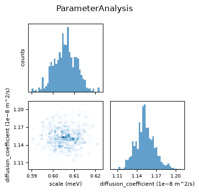

Notice that these credible intervals are **much narrower** than the uncertainties printed further up, and that difference is worth understanding rather than trusting.

Neither is simply right. The gap is a signal that the two-step model is not capturing the data, which is exactly what we address next by fitting the diffusion model to all the data at once.

This is a good result, but we can do better. Now that we know that the quasielastic scattering is well described by a model of diffusion, we can fit this model directly to the data, fitting all $Q$ simultaneously.

In addition to this diffusion model, we will still fit the elastic incoherent scattering.

We create a new `SampleModel` which as a `DeltaFunction` component for the elastic incoherent scattering and a `BrownianTranslationalDiffusion` diffusion model to describe the rest. We also create a new `BackgroundModel` and `InstrumentModel`.

```python
delta_function = edyn.DeltaFunction(name='DeltaFunction', area=0.2)
component_collection = edyn.ComponentCollection(
    components=[delta_function],
)
diffusion_model = edyn.BrownianTranslationalDiffusion(
    name='Brownian Translational Diffusion', diffusion_coefficient=2.4e-9, scale=0.5
)

sample_model = edyn.SampleModel(
    components=component_collection,
    diffusion_models=diffusion_model,
)

background_model = edyn.BackgroundModel(components=edyn.Polynomial(coefficients=[0.001]))
```

delta_function = edyn.DeltaFunction(name='DeltaFunction', area=0.2) component_collection = edyn.ComponentCollection( components=[delta_function], ) diffusion_model = edyn.BrownianTranslationalDiffusion( name='Brownian Translational Diffusion', diffusion_coefficient=2.4e-9, scale=0.5 ) sample_model = edyn.SampleModel( components=component_collection, diffusion_models=diffusion_model, ) background_model = edyn.BackgroundModel(components=edyn.Polynomial(coefficients=[0.001]))

```python
instrument_model = edyn.InstrumentModel(
    background_model=background_model,
    resolution_model=vanadium_analysis.sample_model,
)
```

instrument_model = edyn.InstrumentModel( background_model=background_model, resolution_model=vanadium_analysis.sample_model, )

We attach all our models to a new `Analysis` object.

```python
diffusion_model_analysis = edyn.Analysis(
    display_name='Diffusion Full Analysis',
    experiment=diffusion_experiment,
    sample_model=sample_model,
    instrument_model=instrument_model,
)

diffusion_model_analysis.instrument_model.resolution_model.fix_all_parameters()
```

diffusion_model_analysis = edyn.Analysis( display_name='Diffusion Full Analysis', experiment=diffusion_experiment, sample_model=sample_model, instrument_model=instrument_model, ) diffusion_model_analysis.instrument_model.resolution_model.fix_all_parameters()

As always, we first check the start parameters before we fit

```python
diffusion_model_analysis.plot_data_and_model()
```

diffusion_model_analysis.plot_data_and_model()

We can now fit all the data simultaneously to our model. It looks good!

```python
diffusion_model_analysis.fit(fit_method='simultaneous')
diffusion_model_analysis.plot_data_and_model(ymax=2)
```

diffusion_model_analysis.fit(fit_method='simultaneous') diffusion_model_analysis.plot_data_and_model(ymax=2)

```
CollectionBase is deprecated and will be removed in a future version. Please migrate to ModelBase or EasyList.
```

It does not make sense to plot the diffusion parameters, as they are just two numbers with uncertainties, but we can display them (with uncertainties) like this.

```python
diffusion_model.get_global_variables()
```

diffusion_model.get_global_variables()

```
[<Parameter 'diffusion_coefficient': 1.126e-08 ± 9.799e-11 m^2/s, bounds=[0.0:inf]>,
 <Parameter 'scale': 0.6938 ± 0.0043 meV, bounds=[0.0:inf]>]
```

For reference, here are the diffusion parameters found from fitting the width and scale of the fitted Lorentzians. Notice that the error bars when fitting everything simultaneously are a lot lower than the two-step fit.

```python
parameter_analysis.get_all_variables()
```

parameter_analysis.get_all_variables()

```
[<Parameter 'scale': 0.6062 ± 0.0426 meV, bounds=[0.0:1.1535741578545182]>,
 <Parameter 'diffusion_coefficient': 1.152e-08 ± 1.248e-09 m^2/s, bounds=[0.0:2.6303236476482962e-08]>]
```